# Data Analysis - Douglas Color Cards

## Introduction to task

Following report discusess the findings of qunatitative analysis that was conducted on printing samples of Doglus Color Card. It also outlines the walkthrough of process that was followed for the said excercise.

### Dataset and Quality Assesment Criteria

The dataset contains measurments of color cards that were taken from a random batch of production. Thirteen printed sheets were sampled for examining printing quality. Similarity in color measurments was considered to be the quality criteria for color printing. Colors were measured on CIELAB colorspace, the industry standard metric for defining colors in printing. Each of the colorsheet had 42 color cards/targetsm, that were arranged in 7 rows and 6 columns. Furthermore, each color card had 64 color spots with different color print.

#### Delta E (ΔE)

The measure of change in visual perception of two given colors can be determined by qunatitative means. Delta E76 could be one possilbe tool for doing such calculation. Quantifying visual perception difference can help us infer the degree of similarity or dissimilarity of color prints.

Note: For the course of discussion, hereafter, we would assume that master card is the reference/intended card for printing.

#### Color-Difference Perception table

On a typical scale, the Delta E value ranges from 0 to 100. Following table shows the delta E and its perception by human eye;

| Delta E | Color-Difference Perception |
| --- | --- |
| <= 1.0 | Not perceptible by human eyes. |
| 1 - 2 | Perceptible through close observation |
| 2 - 10 | Perceptible at a glance |
| 11 - 49 | Colors are more similar than opposite |
| 100 | Colors are exact opposite |

Source: http://zschuessler.github.io/DeltaE/learn/

## Walkthrough of process and possible questions

The steps that were used for the anlysis are as follow:

- Color measurements for master card and measurment cards were in two different formats. Data transformation techniques were applied to reformat data in same format
- Color measurements were aggregated over sheets, cards and colorspots by using group by operator, and taking average of color measure
- Color variation was examined for colorspot in indivisual color channels and for colorspot as whole
- Visual perception difference of measurement cards and master cards by using delta E76
- Effect of indivisual channel on color variation was examined
- And finally, intresting insights were recorded and presented using different graphs and other visual aids

## Findings

### 1. Color Dispersion

#### a. Channel Similarity of Master vs Measurements

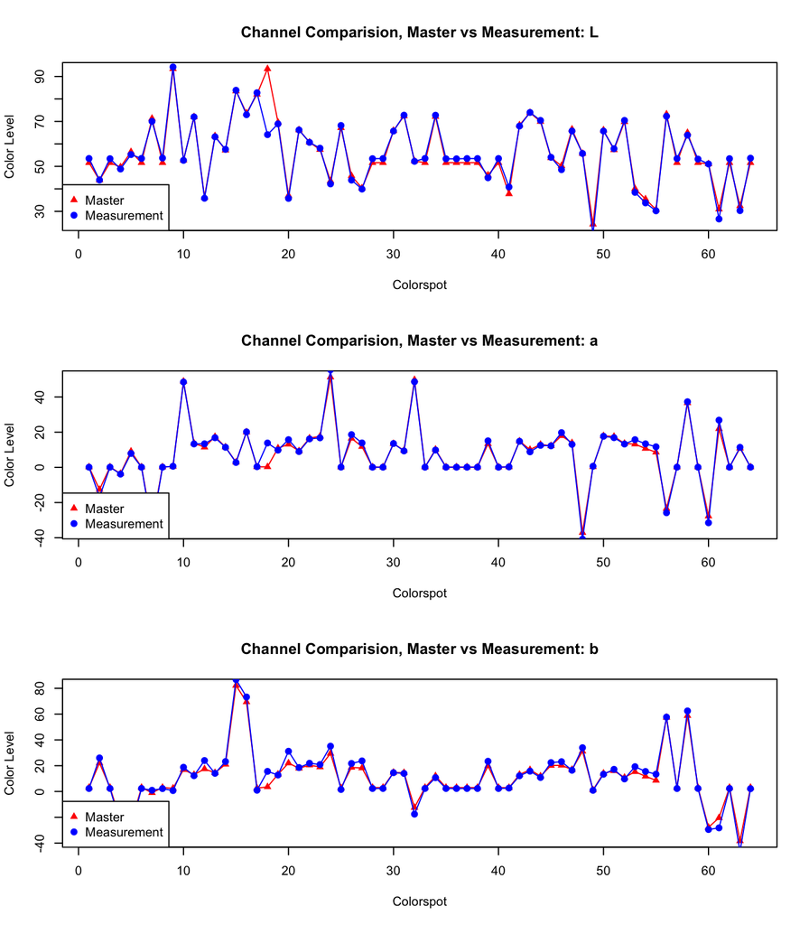

```r
# dimension comparision
  deltaE <- getColorDifferenceDf(datMaster, measrmnts_grouped_by_colorspot[-1:-2])

  par(mfrow=c(3,1))

  # L
    plot(
      datMaster$L, type = "o", col = 10, pch=17, xlab="Colorspot", ylab = "Color Level", main = "Channel Comparision, Master vs Measurement: L")
    lines(measrmnts_grouped_by_colorspot$L, type = "o", col = 100, pch=19)
    legend("bottomleft",
      legend = c("Master", "Measurement"),
      col = c(10,100),
      pch = c(17,19)
    )

  # A
  plot(
    datMaster$a, type = "o", col = 10, pch=17, xlab="Colorspot", ylab = "Color Level", main = "Channel Comparision, Master vs Measurement: a")
  lines(measrmnts_grouped_by_colorspot$a, type = "o", col = 100, pch=19)
  legend("bottomleft",
    legend = c("Master", "Measurement"),
    col = c(10,100),
    pch = c(17,19)
  )

  # B
  plot(
    datMaster$b, type = "o", col = 10, pch=17, xlab="Colorspot", ylab = "Color Level", main = "Channel Comparision, Master vs Measurement: b")
  lines(measrmnts_grouped_by_colorspot$b, type = "o", col = 100, pch=19)
  legend("bottomleft",
    legend = c("Master", "Measurement"),
    col = c(10,100),
    pch = c(17,19)
  )
```

#### b. Measurements behaviour relative to Master in Lab Colorpace

- All the values of L,a and b going far from 0,0,0 on 3d lab space.
- Luminance changes barely (L)
- green-red Values which is far from 0 getting more far but not those which are close to 0(a)
- blue/yellow getting more darker(b)

```r
  plot3d( MasterColorCard[,9:11][,1], MasterColorCard[,9:11][,2], MasterColorCard[,9:11][,3], col = "red" , xlab="Luminance", ylab="a(green-red)", zlab="b(blue-yellow)", size = 5)
```

[interactive chart not shown]

```r
  plot3d( avg_color_sheet[,1:3][,1], avg_color_sheet[,1:3][,2], avg_color_sheet[,1:3][,3], add=TRUE,size=5)
```

[interactive chart not shown]

- Color Dispersion On 3d Lab Color space on Master (L,a,b) values
- Bigger the circle higher the dispersion

```r
  abs_diff<-avg_color_sheet[,1:3]-MasterColorCard[,9:11]

  plot3d( MasterColorCard[,9:11][,1], MasterColorCard[,9:11][,2],
          MasterColorCard[,9:11][,3], xlab="Luminance", ylab="a", zlab="b", type="s", radius = apply((abs_diff),MARGIN=1,FUN=mean),lit=TRUE)
```

[interactive chart not shown]

#### c. Coorelation: Master vs Measurements

- Visible coorelation between color channels of master cards and measurements

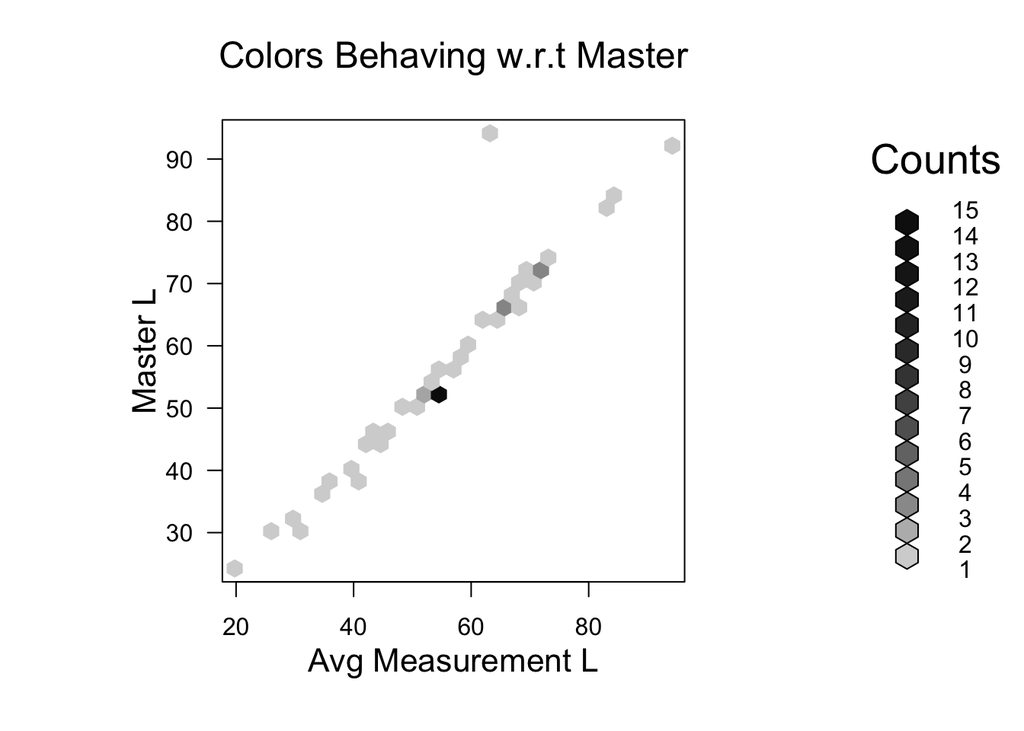

```r
###How do color chanels behave relative to the print master?

# par(mfrow=c(1,3))

plot(hexbin(avg_color_sheet$L,MasterColorCard$L),  xlab="Avg Measurement L", ylab="Master L", main="Colors Behaving w.r.t Master")
```

```r
# plot(hexbin(avg_color_sheet$a,MasterColorCard$a),  xlab="Avg Measurement a", ylab="Master a", main="Colors Behaving w.r.t Master")
# plot(hexbin(avg_color_sheet$b,MasterColorCard$b),  xlab="Avg Measurement b", ylab="Master b", main="Colors Behaving w.r.t Master")
```

#### d. Color Dispersion over sheet

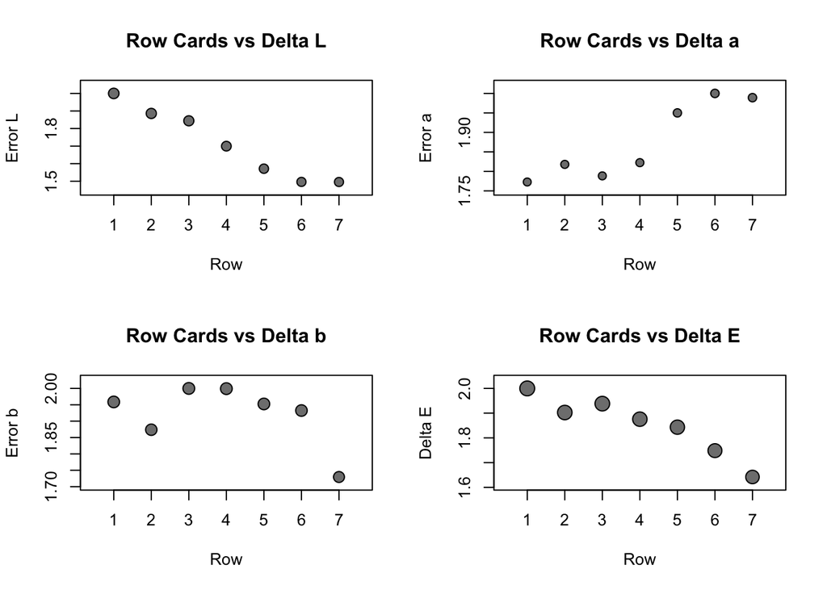

```r
###How does color dispersion behave?
delta_l_byTargetRow<-apply(pos@delta_l, 1, mean)
delta_a_byTargetRow<-apply(pos@delta_a, 1, mean)
delta_b_byTargetRow<-apply(pos@delta_b, 1, mean)
delta_e_byTargetRow<-apply(pos@delta_e, 1, mean)



index<-seq(1:7)

par(mfrow=c(2,2))

symbols(index, 2*delta_l_byTargetRow/max(delta_l_byTargetRow), circles=sqrt(delta_l_byTargetRow/100), bg="grey50", inches=FALSE, xlab="Row", ylab="Error L", main="Row Cards vs Delta L")
symbols(index, 2*delta_a_byTargetRow/max(delta_a_byTargetRow), circles=sqrt(delta_a_byTargetRow/100), bg="grey50", inches=FALSE, xlab="Row", ylab="Error a", main="Row Cards vs Delta a")
symbols(index, 2*delta_b_byTargetRow/max(delta_b_byTargetRow), circles=sqrt(delta_b_byTargetRow/100), bg="grey50", inches=FALSE, xlab="Row", ylab="Error b",main="Row Cards vs Delta b")
symbols(index, 2*delta_e_byTargetRow/max(delta_e_byTargetRow), circles=sqrt(delta_e_byTargetRow/100), bg="grey50", inches=FALSE, xlab="Row", ylab="Delta E", main="Row Cards vs Delta E")
```

- Color Dispersion By Sheet Column
  - Column 6 has least degree of visible difference perception
  - Column 3 has highest degree of visible difference perception

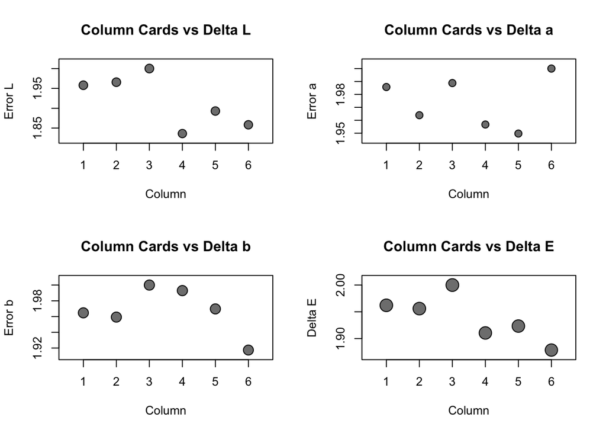

```r
###How does color dispersion behave?
delta_l_byTargetRow<-apply(pos@delta_l, 2, mean)
delta_a_byTargetRow<-apply(pos@delta_a, 2, mean)
delta_b_byTargetRow<-apply(pos@delta_b, 2, mean)
delta_e_byTargetRow<-apply(pos@delta_e, 2, mean)



index<-seq(1:6)

par(mfrow=c(2,2))

symbols(index, 2*delta_l_byTargetRow/max(delta_l_byTargetRow), circles=sqrt(delta_l_byTargetRow/100), bg="grey50", inches=FALSE, xlab="Column", ylab="Error L", main="Column Cards vs Delta L")
symbols(index, 2*delta_a_byTargetRow/max(delta_a_byTargetRow), circles=sqrt(delta_a_byTargetRow/100), bg="grey50", inches=FALSE, xlab="Column", ylab="Error a", main="Column Cards vs Delta a")
symbols(index, 2*delta_b_byTargetRow/max(delta_b_byTargetRow), circles=sqrt(delta_b_byTargetRow/100), bg="grey50", inches=FALSE, xlab="Column", ylab="Error b", main="Column Cards vs Delta b")
symbols(index, 2*delta_e_byTargetRow/max(delta_e_byTargetRow), circles=sqrt(delta_e_byTargetRow/100), bg="grey50", inches=FALSE, xlab="Column", ylab="Delta E", main="Column Cards vs Delta E")
```

#### f. Similarity within average card (amongst colorpsots)

- colorspot 3x2 is least similar (delta E)
- colorspot in delta b has most differences as compared to other two dimensions

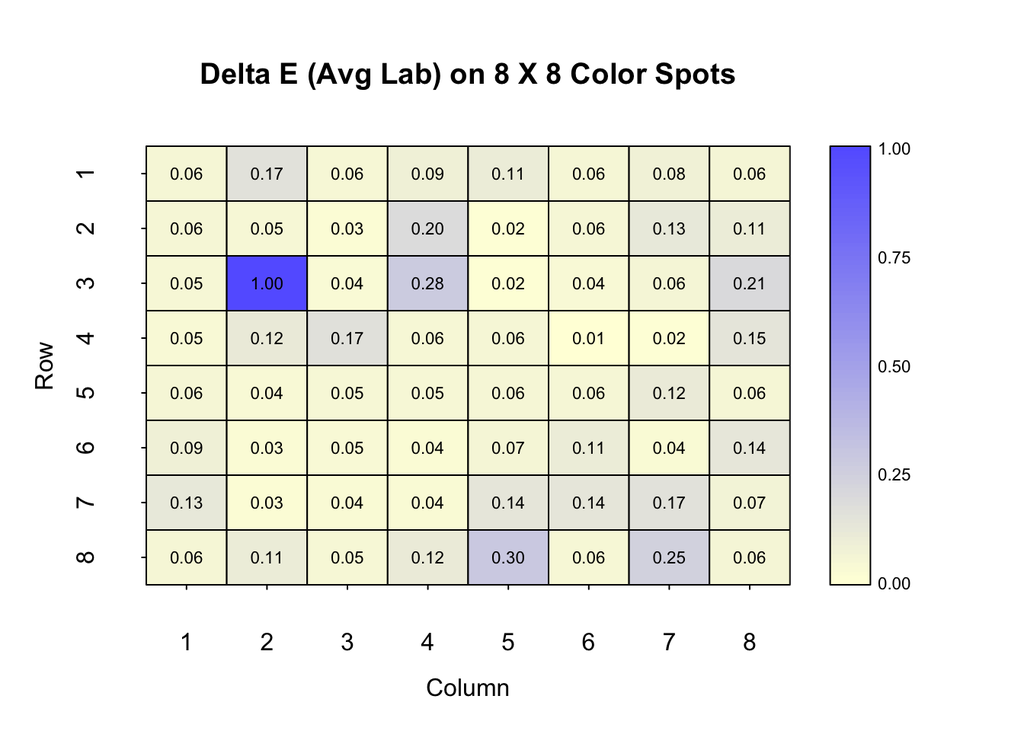

```r
generate_nxn_matrix<-function(delta)
{
  delta_e_matrix<-matrix(, nrow = 8, ncol = 8)
  lower<-1
  for (i in 1:8){
    upper<-lower+7
    temp<-delta[lower:upper]
    if (i<2){
      delta_e_matrix<-rbind(temp)
    }
    else{
      #print(temp)
      delta_e_matrix=rbind(delta_e_matrix,temp)
      #print(delta_e_matrix)
    }
    lower<-lower+8
  }
  return (delta_e_matrix)
}

generate_color_palette<-function(delta, delta_title)
{
  library(plotrix)

  #Build the matrix data to look like a correlation matrix
  n <- 8
  x <- delta/max(delta)
  xmin <- 0
  xmax <- 1
  #for (i in 1:n) x[i, i] <- 1.0 #Make the diagonal all 1's

  #Generate the palette for the matrix and the legend.  Generate labels for the legend
  palmat <- color.scale(x, c(1, 0.4), c(1, 0.4), c(0.86, 1))
  palleg <- color.gradient(c(1, 0.4), c(1, 0.4), c(0.86, 1), nslices=100)
  lableg <- c(formatC(xmin, format="f", digits=2), formatC(1*(xmax-xmin)/4, format="f", digits=2), formatC(2*(xmax-xmin)/4, format="f", digits=2), formatC(3*(xmax-xmin)/4, format="f", digits=2), formatC(xmax, format="f", digits=2))

  #Set up the plot area and plot the matrix
  par(mar=c(5, 5, 5, 8))
  color2D.matplot(x, cellcolors=palmat, main=paste(delta_title, " on ", n, " X ", n, " Color Spots", sep=""), show.values=2, vcol=rgb(0,0,0), axes=FALSE, vcex=0.7)
  axis(2, at=seq(1, n, 1)-0.5, labels=seq(n, 1, -1), tck=-0.01, padj=-1)
  axis(1, at=seq(1, n, 1)-0.5, labels=seq(1, n, 1), tck=-0.01, padj=0.7)

  #Plot the legend
  pardat <- par()
  color.legend(pardat$usr[2]+0.5, 0, pardat$usr[2]+1, pardat$usr[2], paste(" ", lableg, sep=""), palleg, align="rb", gradient="y", cex=0.7)

}

###How does color dispersion behave?
delta_l<-getColorDifference(MasterColorCard,avg_color_sheet,"L")
delta_a<-getColorDifference(MasterColorCard,avg_color_sheet,"a")
delta_b<-getColorDifference(MasterColorCard,avg_color_sheet,"b")
delta_e<-getColorDifference(MasterColorCard,avg_color_sheet,"all")

# par(mfrow=c(2,2))

delta_e_matrix<-generate_nxn_matrix(delta_e)
generate_color_palette(delta_e_matrix,"Delta E (Avg Lab)")
```

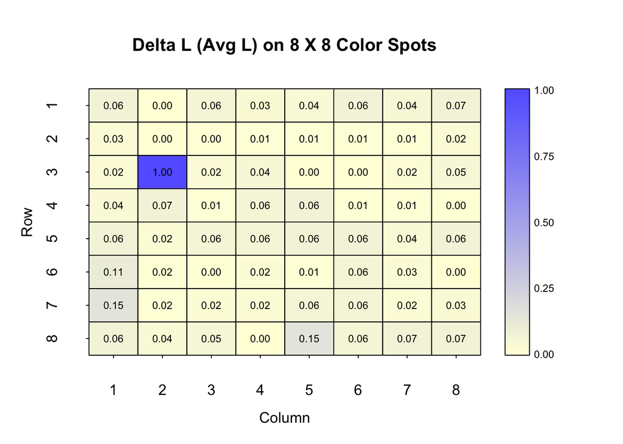

```r
delta_L_matrix<-generate_nxn_matrix(delta_l)
generate_color_palette(delta_L_matrix,"Delta L (Avg L)")
```

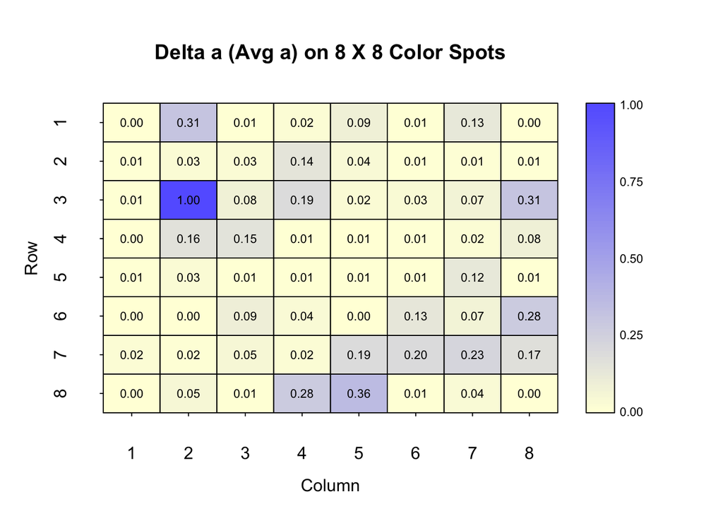

```r
delta_a_matrix<-generate_nxn_matrix(delta_a)
generate_color_palette(delta_a_matrix,"Delta a (Avg a)")
```

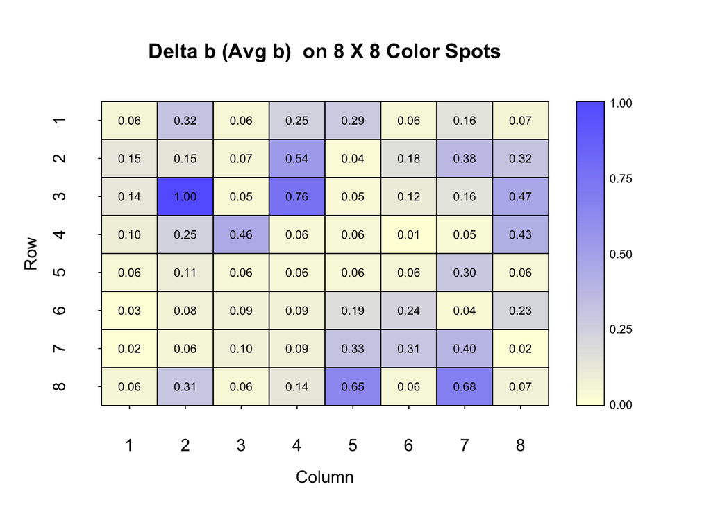

```r
delta_b_matrix<-generate_nxn_matrix(delta_b)
generate_color_palette(delta_b_matrix,"Delta b (Avg b) ")
```

### 2. Influence of channels on Delta E

#### a. Correlation between Delta E and Channels

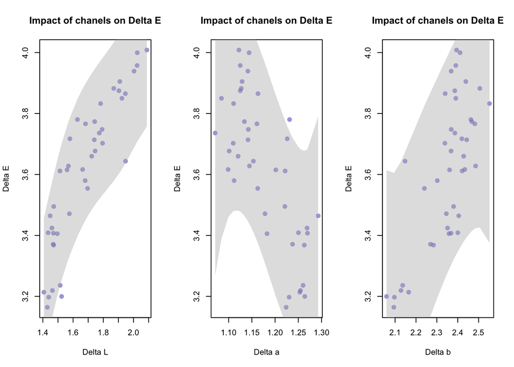

```r
###Which color chanel contributes more to error?
impact_on_error<-function(delta_e, delta, x_title, ..){

  # We create 2 vectors x and y. It is a polynomial function.
  x <- delta
  y <-  delta_e

  # Basic plot of x and y :
  plot(x,y,col=rgb(0.4,0.4,0.8,0.6), pch=16 , cex=1.3 , xlab=x_title , ylab="Delta E", main=paste("Impact of chanels on Delta E"))

  # Can we find a polynome that fit this function ?
  model=lm(y ~ x + I(x^2) + I(x^3))

  # I can get the features of this model :
  summary(model)
  model$coefficients
  summary(model)$adj.r.squared


  suppressWarnings({

      #For each value of x, I can get the value of y estimated by the model, and the confidence interval around this value.
      myPredict <- predict( model , interval="predict" )

      #Finally, I can add it to the plot using the line and the polygon function with transparency.
      ix <- sort(x,index.return=T)$ix
      #lines(x[ix], myPredict[ix , 1], col=2, lwd=2 )
      polygon(c(rev(x[ix]), x[ix]), c(rev(myPredict[ ix,3]), myPredict[ ix,2]), col = rgb(0.7,0.7,0.7,0.4) , border = NA)

    })


}

delta_e_flatten<-as.vector(t(pos@delta_e))
delta_l_flatten<-as.vector(t(pos@delta_l))
delta_a_flatten<-as.vector(t(pos@delta_a))
delta_b_flatten<-as.vector(t(pos@delta_b))

par(mfrow=c(1,3))

impact_on_error(delta_e_flatten, delta_l_flatten, "Delta L")
impact_on_error(delta_e_flatten, delta_a_flatten, "Delta a")
impact_on_error(delta_e_flatten, delta_b_flatten, "Delta b")
```

#### b. Impact of Delta E vs Delta L/a/b

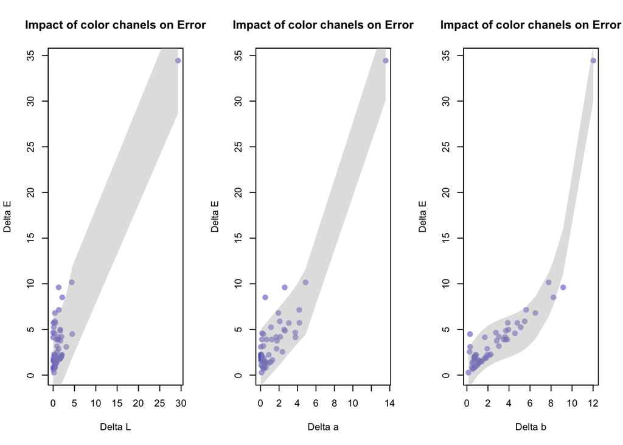

```r
###Which color chanel contributes more to error?
impact_on_error<-function(delta_e, delta, x_title, ..){

# We create 2 vectors x and y. It is a polynomial function.
x <- delta
y <-  delta_e

# Basic plot of x and y :
plot(x,y,col=rgb(0.4,0.4,0.8,0.6), pch=16 , cex=1.3 , xlab=x_title , ylab="Delta E", main=paste("Impact of color chanels on Error"))

# Can we find a polynome that fit this function ?
model=lm(y ~ x + I(x^2) + I(x^3))

# I can get the features of this model :
summary(model)
model$coefficients
summary(model)$adj.r.squared

 suppressWarnings({
    #For each value of x, I can get the value of y estimated by the model, and the confidence interval around this value.
    myPredict <- predict( model , interval="predict" )

    #Finally, I can add it to the plot using the line and the polygon function with transparency.
    ix <- sort(x,index.return=T)$ix
    #lines(x[ix], myPredict[ix , 1], col=2, lwd=2 )
    polygon(c(rev(x[ix]), x[ix]), c(rev(myPredict[ ix,3]), myPredict[ ix,2]), col = rgb(0.7,0.7,0.7,0.4) , border = NA)
 })

}

par(mfrow=c(1,3))

impact_on_error(delta_e, delta_l, "Delta L")
impact_on_error(delta_e, delta_a, "Delta a")
impact_on_error(delta_e, delta_b, "Delta b")
```

### 3. General Obervations

#### Distribution Comparision of Master vs Avg. Measurements

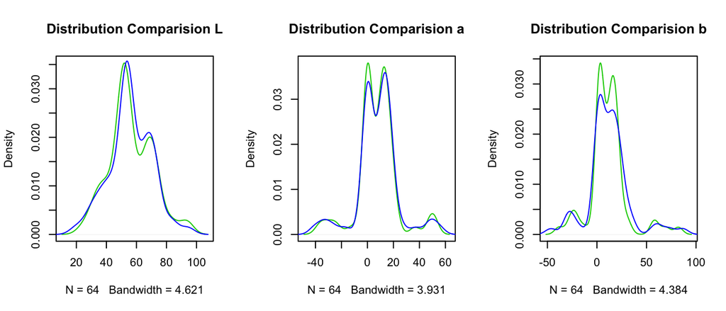

```r
# distribution comparision
# iterate measurments

  deltaE <- getColorDifferenceDf(datMaster, measrmnts_grouped_by_colorspot[-1:-2])

  par(mfrow=c(1,3))

  # L
  plot(density(datMaster$L), col="3", main="Distribution Comparision L")
  lines(density(measrmnts_grouped_by_colorspot$L), col="4")

  # A
  plot(density(datMaster$a), col="3", main="Distribution Comparision a")
  lines(density(measrmnts_grouped_by_colorspot$a), col="4")

  # B
  plot(density(datMaster$b), col="3", main="Distribution Comparision b")
  lines(density(measrmnts_grouped_by_colorspot$b), col="4")
```